# Modeling Assignment Using H2O AutoML

Stephen Smart

2023-03-31

# Introduction

The goal of this document is to provide a solution that can allow for Swire to predict the expected number of transactions per year for a given customer, where the expected number of transactions per year is:

**Total transactions/max(maxdate)-min(mindate)**

From there, the salesperson could take the predicted value and multiply it by [x] years to get a forecast.

I wanted to focus on model usability, where the inputs could be completely derived using only information that we would know about the customer from the start.

```
##
##
## • Dig deeper into tidy modeling with R at https://www.tmwr.org
##
##
##
##
```

```r
set.seed(1)
```

# Data preparation

To start, we first need to retrieve the data from the database. The following tables are in the database

- **customer** - Customer data provided by Swire.
- **customer_features** - Features that were engineered by my teammate Alvaro.
- **sales** - Sales data provided by Swire.
- **acs** - American Community Survey data pulled from the census api

In this document, we will only be using, customer, and customer features, as customer contains all of the customer information, and customer features contains our target variable.

The sales data is not needed, and was only used to derive features. The acs data set did not prove to be effective when using it to predict expected number of transactions per year.

```
## [1] "Querying customer"
## [1] "Querying customer_features"
```

```
## [1] TRUE
```

As mentioned before, I wanted to only select variables that a salesperson would use if we were forecasting the expected number of transactions for a new customer.

I am using the following variables in this model:

- **Predictors:**
  - CUSTOMER_TRADE_CHANNEL_DESCRIPTION - Type of store the customer falls under (Supermarket, College, etc.)
  - CUSTOMER_SUB_TRADE_CHANNEL_DESCRIPTION - More specific type of store the customer falls under (Chain Supermarket, Hardware, etc.)
  - ADDRESS_CITY - City in which the customer resides
- **Target:**
  - EXPECTED_TRANS_YEAR

Other variables were previously tested, such as County, but they proved to show no impact on how many transactions a business makes a month.

I then created a lasso regression model to provide insight on which trade channels were having the most influence on expected number of transactions per year. While not all channels are significant, we can see that some do show influence.

```r
x <- model.matrix(EXPECTED_TRANS_YEAR ~ ., data = df)[,-1]
y <- df$EXPECTED_TRANS_YEAR
fit <- cv.glmnet(x, y, alpha = 1)
coef(fit)
```

```
## 1396 x 1 sparse Matrix of class "dgCMatrix"
##                                                                       s1
## (Intercept)                                                 3.363975e+02
## ADDRESS_CITYACEQUIA                                         .
## ADDRESS_CITYACME                                            .
## ADDRESS_CITYADRIAN                                          .
## ADDRESS_CITYAHSAHKA                                         .
## ADDRESS_CITYAIRWAY HEIGHTS                                  .
## ADDRESS_CITYAJO                                             .
## ADDRESS_CITYAKRON                                           .
## ADDRESS_CITYALAMO                                           .
## ADDRESS_CITYALAMOSA                                         .
## ADDRESS_CITYALBANY                                          .
## ADDRESS_CITYALBION                                          .
## ADDRESS_CITYALBUQUERQUE                                     .
## ADDRESS_CITYALGODONES                                       .
## ADDRESS_CITYALGONA                                          .
## ADDRESS_CITYALLENSPARK                                      .
## ADDRESS_CITYALLIANCE                                        .
## ADDRESS_CITYALLYN                                           .
## ADDRESS_CITYALMO                                            .
## ADDRESS_CITYALMONT                                          .
## ADDRESS_CITYALPINE                                          .
## ADDRESS_CITYALTA                                            .
## ADDRESS_CITYAMADO                                           .
## ADDRESS_CITYAMBOY                                           .
## ADDRESS_CITYAMERICAN FALLS                                  .
## ADDRESS_CITYAMERICAN FORK                                   .
## ADDRESS_CITYAMITY                                           .
## ADDRESS_CITYAMMON                                           .
## ADDRESS_CITYANACORTES                                       .
## ADDRESS_CITYANGEL FIRE                                      .
## ADDRESS_CITYANTELOPE                                        .
## ADDRESS_CITYANTHEM                                          .
## ADDRESS_CITYANTIMONY                                        .
## ADDRESS_CITYANTONITO                                        .
## ADDRESS_CITYAPACHE JUNCTION                                 .
## ADDRESS_CITYARAPAHOE                                        .
## ADDRESS_CITYARCO                                            .
## ADDRESS_CITYARIZONA CITY                                    .
```

[output cut: 1343 more lines]

```
## CUSTOMER_SUB_TRADE_CHANNEL_DESCRIPTIONPrimary School        .
## CUSTOMER_SUB_TRADE_CHANNEL_DESCRIPTIONQSR-Asian             .
## CUSTOMER_SUB_TRADE_CHANNEL_DESCRIPTIONQSR-Chicken           .
## CUSTOMER_SUB_TRADE_CHANNEL_DESCRIPTIONQSR-Hamburger         .
## CUSTOMER_SUB_TRADE_CHANNEL_DESCRIPTIONQSR-Mexican           .
## CUSTOMER_SUB_TRADE_CHANNEL_DESCRIPTIONQSR-Other Fast Food   .
## CUSTOMER_SUB_TRADE_CHANNEL_DESCRIPTIONQSR-Pizza             9.964994e+01
## CUSTOMER_SUB_TRADE_CHANNEL_DESCRIPTIONQSR-Sandwich          .
## CUSTOMER_SUB_TRADE_CHANNEL_DESCRIPTIONReligious/Charitable  .
## CUSTOMER_SUB_TRADE_CHANNEL_DESCRIPTIONResidential Complex/  .
## CUSTOMER_SUB_TRADE_CHANNEL_DESCRIPTIONSecondary/High Schoo  .
## CUSTOMER_SUB_TRADE_CHANNEL_DESCRIPTIONSocial Club/Fraterna  .
## CUSTOMER_SUB_TRADE_CHANNEL_DESCRIPTIONSport Venue           .
## CUSTOMER_SUB_TRADE_CHANNEL_DESCRIPTIONSports/Country Club   .
## CUSTOMER_SUB_TRADE_CHANNEL_DESCRIPTIONWholesaler            .
```

I then create the train test split to be used for validation.

```r
# Split the 'df' data into training and testing sets
set.seed(1)
data_split <- initial_split(df, prop = 0.7)
training_data <- training(data_split)
testing_data <- testing(data_split)
```

# Modeling process

For modeling, I will be using the auto_ml() function from h2o, which automates the following processes:

- **Candidate models** - By using auto_ml, we are able to work through a set of predetermined black-box models. Auto-ml will attempt to create the following:
  - Three pre-specified XGBoost GBM (Gradient Boosting Machine) models
  - A fixed grid of GLMs
  - A default Random Forest (DRF), five pre-specified H2O GBMs
  - A near-default Deep Neural Net, an Extremely Randomized Forest (XRT)
  - A near-default Deep Neural Net, an Extremely Randomized Forest (XRT)
  - A random grid of Deep Neural Nets
- **Model selection** - Once all models are finished running, auto_ml will rank the models by their specified performance metrics. We will select the best model based on RMSE. We’ll also show the rankings for R2.
- **Cross validation** - By default, auto_ml uses 5 fold cross validation for each of its models.
- **Model tuning** - auto_ml uses grid search, random search, and Bayesian optimization for hyper parameter tuning in each model. In addition, auto_ml uses ensembles to combine the predictive performance of multiple models.
- **Model performance** - Predictions made with the best model are almost instant, but can scale in time depending on the size of the validation set, or new data. The most time consuming part of the model is running auto_ml. The run time of auto_ml can be specified by the user, but most will typically set it between 30 and 60 minutes.

## Specifying the auto_ml process

To facilitate the auto_ml process, we will be using the tidymodels workflow. This creates a procedural method for pre processing and modeling.

The fitting modeling is done with a workflow object. A workflow object is made up of two separate objects:

- **Model** - This includes the engine to be used for making calculations, the modeling task (regression), and any other arguments for the specified engine.
- **Recipe** - The pre processing steps prior to running a model (ex. dummy variables, normalization), and the data to be used.

Here, we’re starting the h2o cluster, then creating the model. We set the engine (what is used to make calculations), the max run time that h2o will run models for, and the mode, which is regression.

```r
# Start H2O cluster
h2o_start()

auto_spec <-
  auto_ml() %>%  # Specify an automatic machine learning workflow
  set_engine("h2o", max_runtime_secs = 1800, seed = 1) %>% # Use h2o as the modeling engine, set maximum runtime to 1800 seconds, and seed to 1
  set_mode("regression") # Set the modeling task to regression
```

This is the recipe, where we set the formula, and the pre processing parameters. Since all the input variables are categorical, no pre processing is necessary outside of the factoring we did earlier.

```r
# Define a recipe object to specify the data preparation steps
data_recipe <-
  recipe(EXPECTED_TRANS_YEAR ~ ., data = training_data)
```

We then combine our model with our recipe into a workflow

```r
auto_workflow <- workflow() %>% # Create a workflow object for the modeling process
  add_recipe(data_recipe) %>% # Add the recipe object created in the previous step to the workflow
  add_model(auto_spec) # Add the automated machine learning model specification object to the workflow
```

Once we have the workflow ready, we fit the model. **This part takes 30 minutes.**

```r
# Fit the AutoML workflow to the training data and store the resulting model in auto_fit
auto_fit <- fit(auto_workflow, data = training_data)
```

The table below shows the ranking of the top performing models across all metrics.

```r
# Extract the model parameters from the AutoML model
extract_fit_parsnip(auto_fit)
```

```
## parsnip model object
##
## ═════════════════════════ H2O AutoML Summary: 79 models ════════════════════════
```

```
## Leader Algorithm: stackedensemble
```

```
## Leader ID: StackedEnsemble_AllModels_3_AutoML_2_20230331_192524
```

```
##
## ══════════════════════════════════ Leaderboard ═════════════════════════════════
##                                                  model_id     rmse      mse
## 1    StackedEnsemble_AllModels_3_AutoML_2_20230331_192524 637.9825 407021.6
## 2 StackedEnsemble_BestOfFamily_4_AutoML_2_20230331_192524 638.2365 407345.8
## 3     StackedEnsemble_Best1000_1_AutoML_2_20230331_192524 638.2439 407355.3
## 4    StackedEnsemble_AllModels_6_AutoML_2_20230331_192524 638.4469 407614.5
## 5 StackedEnsemble_BestOfFamily_6_AutoML_2_20230331_192524 639.0603 408398.1
## 6            GBM_grid_1_AutoML_2_20230331_192524_model_11 639.8364 409390.6
##        mae    rmsle mean_residual_deviance
## 1 302.1765 1.349662               407021.6
## 2 303.3846 1.355789               407345.8
## 3 302.0696 1.349007               407355.3
## 4 302.4028 1.353895               407614.5
## 5 303.7415 1.361289               408398.1
## 6 306.7268      NaN               409390.6
```

We then make predictions on the testing data using the best model. If we wanted to, we could specify a model id to make predictions using one of the other generated models

```r
# Use the AutoML model to make predictions on the testing data
predict(auto_fit, testing_data)
```

```
## # A tibble: 10,500 × 1
##    .pred
##    <dbl>
##  1  227.
##  2  872.
##  3  564.
##  4  411.
##  5  423.
##  6  668.
##  7  248.
##  8  923.
##  9  742.
## 10  277.
## # … with 10,490 more rows
```

This is a table ranking the models from best to worst in terms of RMSE.

```r
# Get the rank results of the AutoML model and pipe the results to the next function
rank_results(auto_fit) %>%
  # Filter the results to only include the metric "rmse"
  filter(.metric == "rmse") %>%
  # Arrange the results in ascending order of rank
  arrange(rank)
```

```
## # A tibble: 79 × 5
##    id                                                algor…¹ .metric  mean  rank
##    <chr>                                             <chr>   <chr>   <dbl> <int>
##  1 StackedEnsemble_AllModels_6_AutoML_2_20230331_19… stacki… rmse     635.     1
##  2 StackedEnsemble_BestOfFamily_6_AutoML_2_20230331… stacki… rmse     635.     2
##  3 StackedEnsemble_AllModels_3_AutoML_2_20230331_19… stacki… rmse     637.     3
##  4 StackedEnsemble_BestOfFamily_4_AutoML_2_20230331… stacki… rmse     637.     4
##  5 StackedEnsemble_Best1000_1_AutoML_2_20230331_192… stacki… rmse     638.     5
##  6 StackedEnsemble_AllModels_4_AutoML_2_20230331_19… stacki… rmse     639.     6
##  7 StackedEnsemble_BestOfFamily_3_AutoML_2_20230331… stacki… rmse     639.     7
##  8 GBM_grid_1_AutoML_2_20230331_192524_model_11      gradie… rmse     639.     8
##  9 StackedEnsemble_AllModels_2_AutoML_2_20230331_19… stacki… rmse     639.     9
## 10 GBM_grid_1_AutoML_2_20230331_192524_model_20      gradie… rmse     639.    10
## # … with 69 more rows, and abbreviated variable name ¹algorithm
```

This is a table ranking the models from best to worst in terms of R2.

```r
# Get the rank results of the AutoML model and pipe the results to the next function
rank_results(auto_fit) %>%
  # Filter the results to only include the metric "r2"
  filter(.metric == "r2") %>%
  # Arrange the results in ascending order of rank
  arrange(rank)
```

```
## # A tibble: 79 × 5
##    id                                                algor…¹ .metric  mean  rank
##    <chr>                                             <chr>   <chr>   <dbl> <int>
##  1 StackedEnsemble_AllModels_3_AutoML_2_20230331_19… stacki… r2      0.169     1
##  2 StackedEnsemble_BestOfFamily_4_AutoML_2_20230331… stacki… r2      0.168     2
##  3 StackedEnsemble_Best1000_1_AutoML_2_20230331_192… stacki… r2      0.168     3
##  4 StackedEnsemble_AllModels_6_AutoML_2_20230331_19… stacki… r2      0.168     4
##  5 StackedEnsemble_BestOfFamily_6_AutoML_2_20230331… stacki… r2      0.165     5
##  6 GBM_grid_1_AutoML_2_20230331_192524_model_11      gradie… r2      0.164     6
##  7 GBM_grid_1_AutoML_2_20230331_192524_model_20      gradie… r2      0.163     7
##  8 GBM_grid_1_AutoML_2_20230331_192524_model_46      gradie… r2      0.163     8
##  9 GBM_grid_1_AutoML_2_20230331_192524_model_1       gradie… r2      0.161     9
## 10 GBM_grid_1_AutoML_2_20230331_192524_model_15      gradie… r2      0.161    10
## # … with 69 more rows, and abbreviated variable name ¹algorithm
```

The code below allows you to export the model to be used in different notebooks or R scripts.

```r
# auto_fit_bundle <- bundle(auto_fit)
# saveRDS(auto_fit_bundle, file = "test.h2o.auto_fit.rds")
```

We can also see the distribution of how every type of model performed. Typically, stacked ensembles work the best.

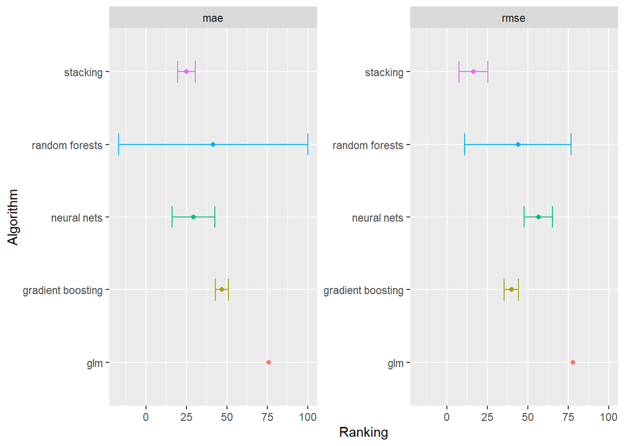

```r
# Plot the performance of all types of AutoML models

# Set the type of plot to "rank" and the metrics to be displayed to "mae" and "rmse"

autoplot(auto_fit, type = "rank", metric = c("mae", "rmse")) +
  # Remove the legend from the plot
  theme(legend.position = "none")
```

# Results

- The top ranked model has an RMSE of 638, and an R2 of .17
- The overall top ranked model among all models was a stacked ensemble

  Without being able to understand more information about the customer, it is difficult to frame this problem as a regression model. Even when we pull demographic information from the census, we still don’t find any signals that directly affect a business’ expected number of transactions per month. Sub channels like Pizza and Supermarket that appeared significant in the lasso model did not end up having strong predictions under the stacked ensemble model.

  If I were to re-approach this problem again, I would make this a clustering model instead.